# Primer paso: Decision Tree

Veamos ahora, algunas métricas más, solo por el mero juego intelectual:

Accuracy (pero de acuerdo al punto de corte):

```r
resultados3[, acc:= ((tp + tn)/(tp+tn+fp+fn))]
```

Desde ahora, el accuracy no es una métrica, se gradua, y se transforma en curva.

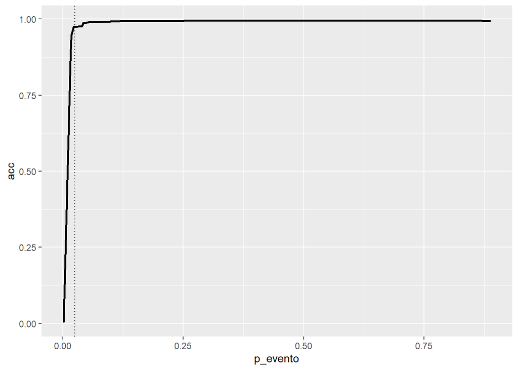

```r
ggplot(resultados3, aes(x=p_evento,y=acc)) +
  geom_line(lwd=1) +
  geom_vline(xintercept = 0.025, linetype="dotted")
```

Los escucho, ¿cuáles son sus conclusiones?

Vamos por otra métrica: F1 Score

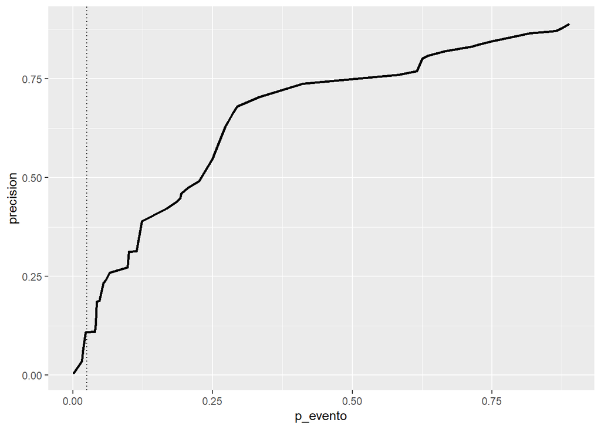

```r
resultados3[,precision := tp / (tp + fp)]
resultados3[,recall := tp / (tp + fn)]
resultados3[,f1 := 2*(precision*recall)/(precision+recall)]

# Graficamos todo

ggplot(resultados3, aes(x=p_evento,y=precision)) +
  geom_line(lwd=1) +
  geom_vline(xintercept = 0.025, linetype="dotted")
```

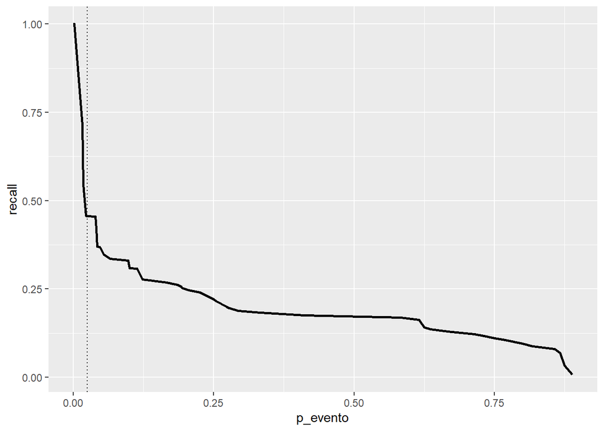

```r
ggplot(resultados3, aes(x=p_evento,y=recall)) +
  geom_line(lwd=1) +
  geom_vline(xintercept = 0.025, linetype="dotted")
```

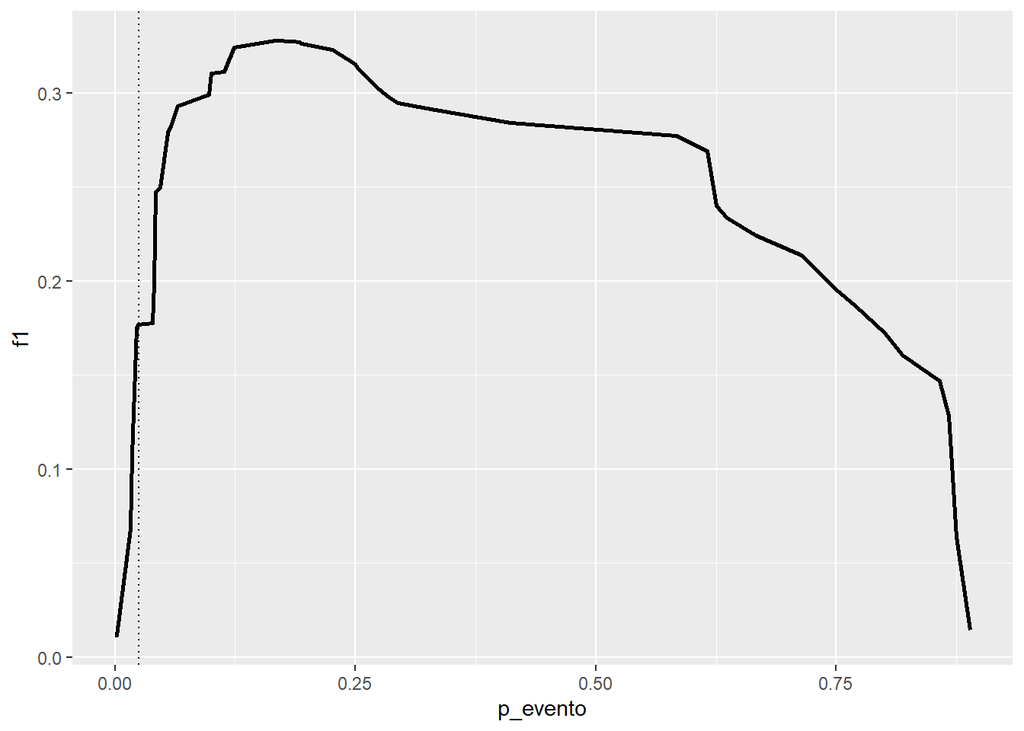

```r
ggplot(resultados3, aes(x=p_evento,y=f1)) +
  geom_line(lwd=1) +
  geom_vline(xintercept = 0.025, linetype="dotted")
```

El la métrica F1, es criticado por dar un mismo peso a `recall` y al `precision`. Por esto mismo, a alguien se le ocurrió el F-Beta:

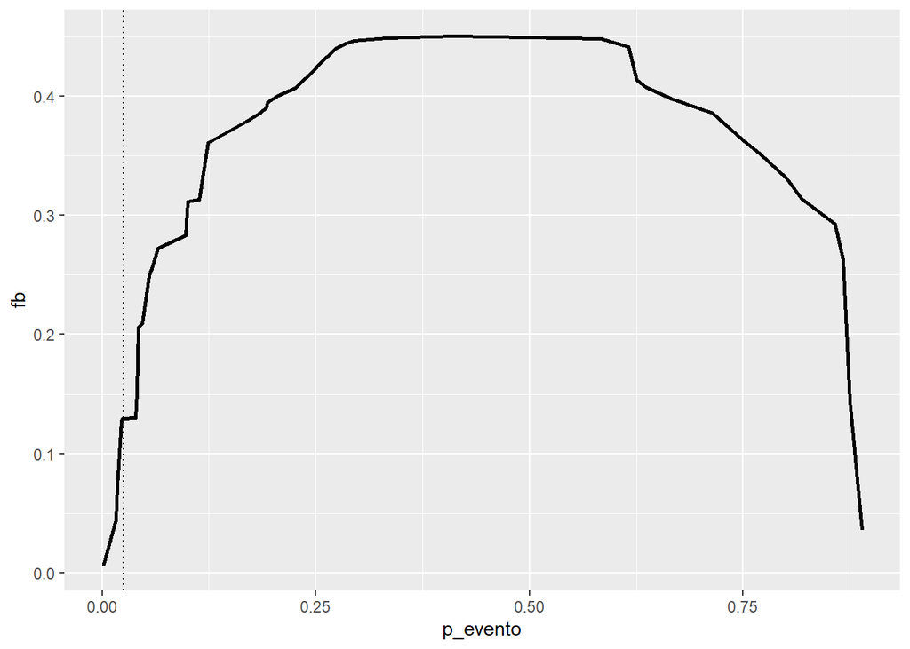

```r
beta <- 0.5 # Da más peso al precision

resultados3[, fb := (1 + beta^2)*(precision*recall)/((beta^2)*precision+recall)]

ggplot(resultados3, aes(x=p_evento,y=fb)) +
  geom_line(lwd=1) +
  geom_vline(xintercept = 0.025, linetype="dotted")
```

Y si cambiamos el Beta:

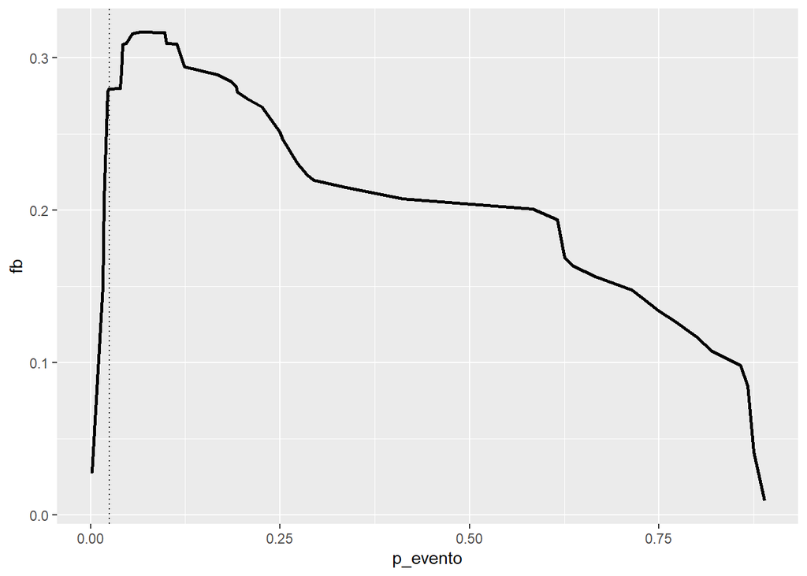

```r
beta <- 2 # Da más peso al recall

resultados3[, fb := (1 + beta^2)*(precision*recall)/((beta^2)*precision+recall)]

ggplot(resultados3, aes(x=p_evento,y=fb)) +
  geom_line(lwd=1) +
  geom_vline(xintercept = 0.025, linetype="dotted")
```

Y vamos por un Beta más alto:

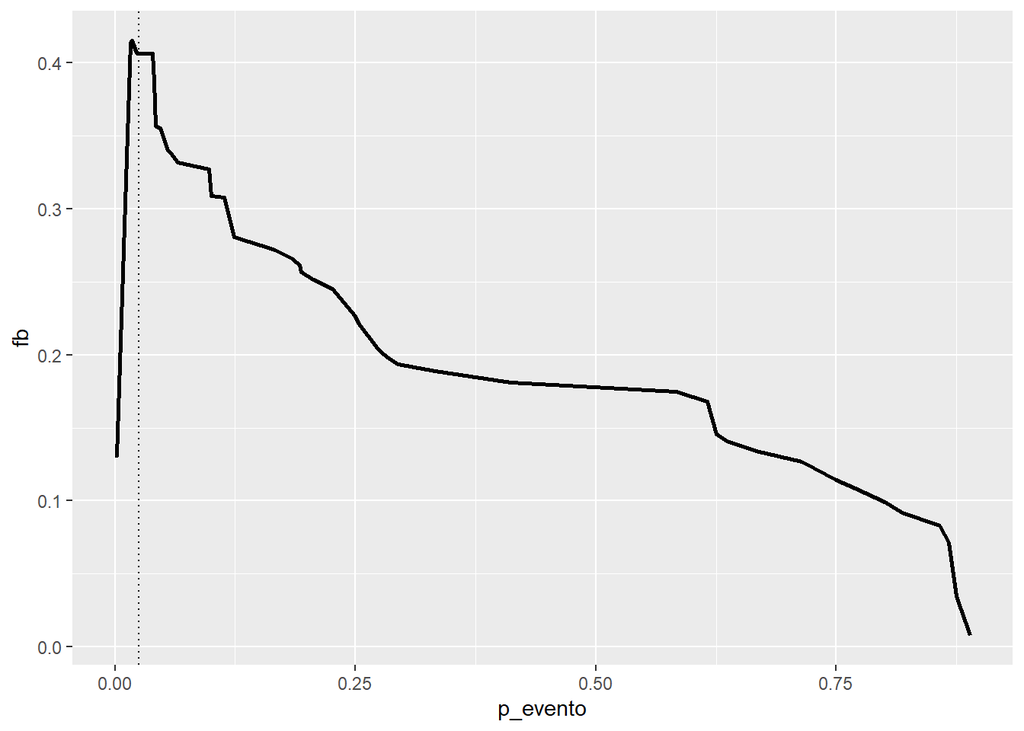

```r
beta <- 5

resultados3[, fb := (1 + beta^2)*(precision*recall)/((beta^2)*precision+recall)]

ggplot(resultados3, aes(x=p_evento,y=fb)) +
  geom_line(lwd=1) +
  geom_vline(xintercept = 0.025, linetype="dotted")
```

¿Conclusiones?

¿Qué otras métricas conoce?

- Implemente en forma casera otras métricas (GINI, KS, Lift, etc…)
- Corte el conjunto de datos en Train/Test y calcule todas las métricas para cada conjunto.
- ¿Ven diferencias entre cada muestra?